# R handout: Computer exercises lecture 4

Maarten Speekenbrink

24 October 2016

## Detecting outliers

What data points are considered outliers depends on your model, so the first step is to set estimate your model with the `lm` function. You can then compute the four outlier detection measures with the following functions:

- Mahalanobis distance: `mahalanobis(x,center,cov,...)` where `x` is a matrix (or `data.frame`) with the predictors for which you want to compute the distance, and `center` a vector with the means of the predictors, and `cov` a covariance matrix for the predictors. For convenience, you can also use the `myMahalanobis` function defined below…
- leverage: `hatvalues(model,...)` where `model` is the estimated regression model (estimated with the `lm` function)
- Studentized deleted residual: `rstudent(model,...)`
- Cook’s distance:`cooks.distance(model,...)`

There are different guidelines as to whether a particular data point is an outlier according to these four measures:

- The Mahalanobis distance follows a $\chi^2$-distribution with $p-1$ degrees of freedom (for $p$ parameters in the model and hence $p-1$ predictors). Usually, when you have a very small sample ($n = 30$) and only two predictors in your model, only values greater than 11 are cause for concern.
- The average leverage value for each participant in the data is $\overline{h} = \frac{p}{n}$ where $p$ is the number of parameters. Individual leverage values that are more than twice or three times the average are cause for concern.
- The studentized deleted residual follows a $t$-distribution with $n-p-1$ degrees of freedom, so you can look up the critical cut-off value in a table of t-values. Make sure to correct your $\alpha$ to take into account that you want a two-sided test and that you’re “running” multiple tests (i.e. to correct for the family-wise error)!
- For Cook’s distance, values greater than 1 or 2 indicate possible problems.

The easiest way to remove the outliers from your data-set is to use the `subset` function, which was discussed in the lab hand-out for lecture 2.

As an example, I will show you how to use these measures with a dataset we analysed last week:

```r
# load the SAWBS data
library(foreign)
geller <- as.data.frame(read.spss("Geller.sav"))
summary(geller)
```

```
##      sawbs           wtpercep        shpercep          hiq
##  Min.   :-47.74   Min.   :1.544   Min.   :1.816   Min.   :-1.981
##  1st Qu.: 30.14   1st Qu.:2.815   1st Qu.:3.469   1st Qu.: 9.829
##  Median : 57.63   Median :3.172   Median :4.196   Median :17.203
##  Mean   : 57.60   Mean   :3.200   Mean   :4.200   Mean   :16.800
##  3rd Qu.: 88.58   3rd Qu.:3.595   3rd Qu.:4.862   3rd Qu.:21.920
##  Max.   :159.66   Max.   :4.688   Max.   :7.084   Max.   :36.246
##     edicomp            rses            bdi              bmi
##  Min.   :-12.67   Min.   :11.20   Min.   :-6.640   Min.   :13.88
##  1st Qu.: 12.75   1st Qu.:30.93   1st Qu.: 6.119   1st Qu.:19.17
##  Median : 23.38   Median :36.62   Median :10.077   Median :21.85
##  Mean   : 22.50   Mean   :36.00   Mean   :10.500   Mean   :21.70
##  3rd Qu.: 33.68   3rd Qu.:40.82   3rd Qu.:15.186   3rd Qu.:24.20
##  Max.   : 67.71   Max.   :54.97   Max.   :32.366   Max.   :28.13
##       ses             socdesir
##  Min.   :-0.7962   Min.   :0.8245
##  1st Qu.: 1.7085   1st Qu.:3.5752
##  Median : 2.2555   Median :4.8711
##  Mean   : 2.3000   Mean   :5.0000
##  3rd Qu.: 2.9869   3rd Qu.:6.3542
##  Max.   : 4.6220   Max.   :8.8968
```

```r
mod <- lm(edicomp~rses+bdi+bmi+sawbs+wtpercep+shpercep,data=geller)
```

### Example of Mahalanobis distance

```r
# compute the Mahalanobis distance for the predictors
# first, lets put the predictors in a matrix called x
predictors <- as.matrix(geller[,c("ses","bdi","bmi","sawbs","wtpercep","shpercep")])
mahal <- mahalanobis(predictors,colMeans(predictors),cov(predictors))
# define a convenience function...
myMahalanobis <- function(x) {
  x <- as.matrix(x)
  mahalanobis(x,colMeans(x),cov(x))
}
mahal <- myMahalanobis(predictors)
summary(mahal)
```

```
##    Min. 1st Qu.  Median    Mean 3rd Qu.    Max.
##  0.8789  3.8100  5.7970  5.9290  7.7550 13.8900
```

```r
## critical value without correction
qchisq(1-.05,df=ncol(predictors))
```

```
## [1] 12.59159
```

```r
# check which observations are above this critical value
which(mahal >= qchisq(1-.05,df=ncol(predictors)))
```

```
## [1] 10
```

```r
# critical value with bonferonni correction
qchisq(1-.05/nrow(geller),df=ncol(predictors))
```

```
## [1] 23.69084
```

```r
# check which observations are above this critical value
which(mahal >= qchisq(1-.05/nrow(predictors),df=ncol(predictors)))
```

```
## integer(0)
```

### Example of leverage

```r
lever <- hatvalues(mod)
# mod has 7 parameters, so a large leverage would be 2*7/n
which(lever > (2*7)/nrow(geller))
```

```
## 61
## 61
```

### Example of Studentized deleted residual

```r
sdr <- rstudent(mod)
## critical value without correction
# note that the t-distribution is two-sided,
# which is why alpha/2 is used below
qt(1-.05/2,df=nrow(geller)-7-1)
```

```
## [1] 1.991673
```

```r
which(abs(sdr) >= qt(1-.05/2,df=nrow(geller)-7-1))
```

```
## 33 34 41 59 63
## 33 34 41 59 63
```

```r
## critical value with bonferonni correction
qt(1-(.05/2)/nrow(geller),df=nrow(geller)-7-1)
```

```
## [1] 3.583904
```

```r
which(abs(sdr) >= qt(1-(.05/2)/nrow(geller),df=nrow(geller)-7-1))
```

```
## named integer(0)
```

### Example of Cooks distance

```r
cooksd <- cooks.distance(mod)
summary(cooksd)
```

```
##      Min.   1st Qu.    Median      Mean   3rd Qu.      Max.
## 5.120e-06 8.623e-04 4.183e-03 1.227e-02 1.473e-02 7.310e-02
```

```r
which(cooksd >= 2)
```

```
## named integer(0)
```

### Selecting cases based on multiple criteria

To select those cases which are *not* likely to be outliers, you can use something like the following:

```r
clean_dat <- subset(geller,cooksd < 2 & abs(sdr) < qt(1-(.05/2)/nrow(geller),df=nrow(geller)-7-1) & lever < (2*7)/nrow(geller) & mahal < qchisq(1-.05/nrow(predictors),df=7))
summary(clean_dat)
```

```
##      sawbs           wtpercep        shpercep          hiq
##  Min.   :-47.74   Min.   :1.544   Min.   :1.957   Min.   :-1.981
##  1st Qu.: 29.02   1st Qu.:2.808   1st Qu.:3.478   1st Qu.: 9.639
##  Median : 56.94   Median :3.170   Median :4.271   Median :17.168
##  Mean   : 56.38   Mean   :3.198   Mean   :4.229   Mean   :16.572
##  3rd Qu.: 88.04   3rd Qu.:3.604   3rd Qu.:4.875   3rd Qu.:21.832
##  Max.   :159.66   Max.   :4.688   Max.   :7.084   Max.   :36.246
##     edicomp            rses            bdi              bmi
##  Min.   :-12.67   Min.   :11.20   Min.   :-6.640   Min.   :13.88
##  1st Qu.: 12.73   1st Qu.:31.16   1st Qu.: 6.085   1st Qu.:19.33
##  Median : 23.10   Median :36.91   Median :10.076   Median :21.88
##  Mean   : 21.96   Mean   :36.24   Mean   :10.354   Mean   :21.75
##  3rd Qu.: 33.65   3rd Qu.:41.00   3rd Qu.:15.021   3rd Qu.:24.22
##  Max.   : 60.22   Max.   :54.97   Max.   :32.366   Max.   :28.13
##       ses             socdesir
##  Min.   :-0.7962   Min.   :0.8245
##  1st Qu.: 1.7139   1st Qu.:3.6270
##  Median : 2.2569   Median :4.9286
##  Mean   : 2.3071   Mean   :5.0212
##  3rd Qu.: 2.9884   3rd Qu.:6.3588
##  Max.   : 4.6220   Max.   :8.8968
```

## Multicollinearity

To assess whether any of your predictors are collinear (i.e. whether there is multicollinearity in your model), you can compute the Variance Inflation Factor through the `vif` function in the `car` package:

```r
# load the car package
library(car)
# compute the VIF for each predictor in the model
vif(mod)
```

```
##     rses      bdi      bmi    sawbs wtpercep shpercep
## 2.747457 3.101769 1.745329 1.331568 2.468101 1.640906
```

The tolerance can be derived from the VIF simply as $frac{1}{\text{VIF}}$, so

```r
# compute the tolerance
1/vif(mod)
```

```
##      rses       bdi       bmi     sawbs  wtpercep  shpercep
## 0.3639730 0.3223967 0.5729578 0.7509942 0.4051699 0.6094196
```

A common heuristic is that tolerance values below .200 and certainly below .100 are cause for concern.

## Predicted-vs.-residuals plot

You can use a predicted-vs.-residuals plot to check whether the assumptions of unbiased and homoscedastic errors are met or violated. From an estimated model, You can create this plot easily yourself as follows:

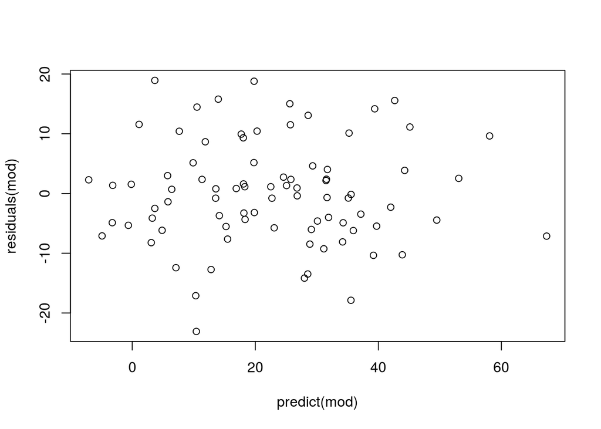

```r
plot(predict(mod),residuals(mod))
```

Alternatively, you can ask for a number of diagnostic plots for an estimated model by calling the `plot` function with the model as first argument:

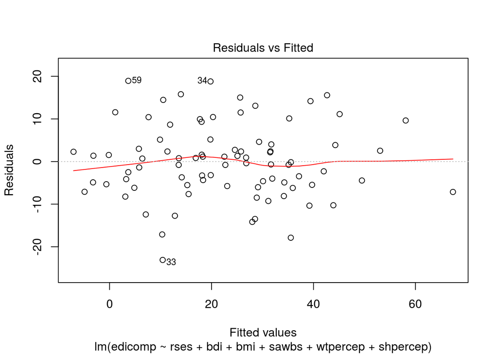

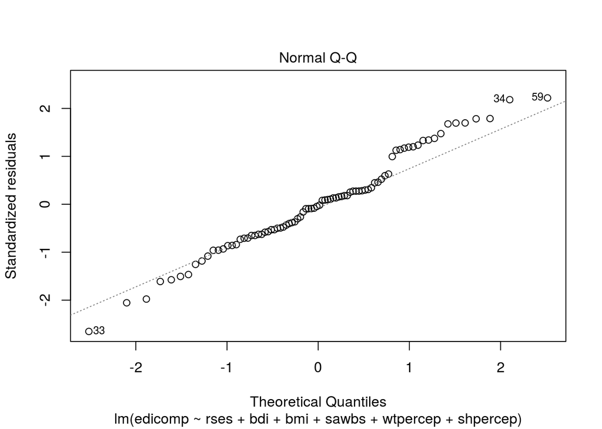

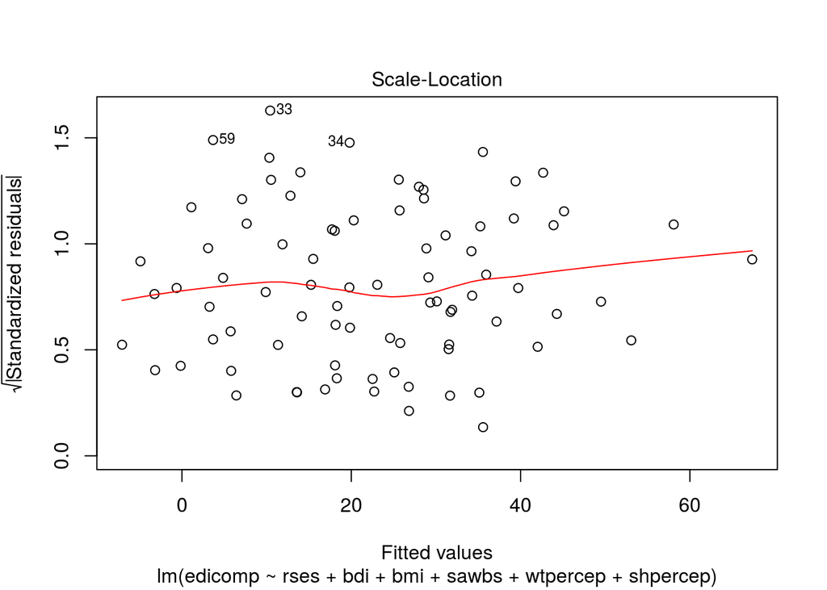

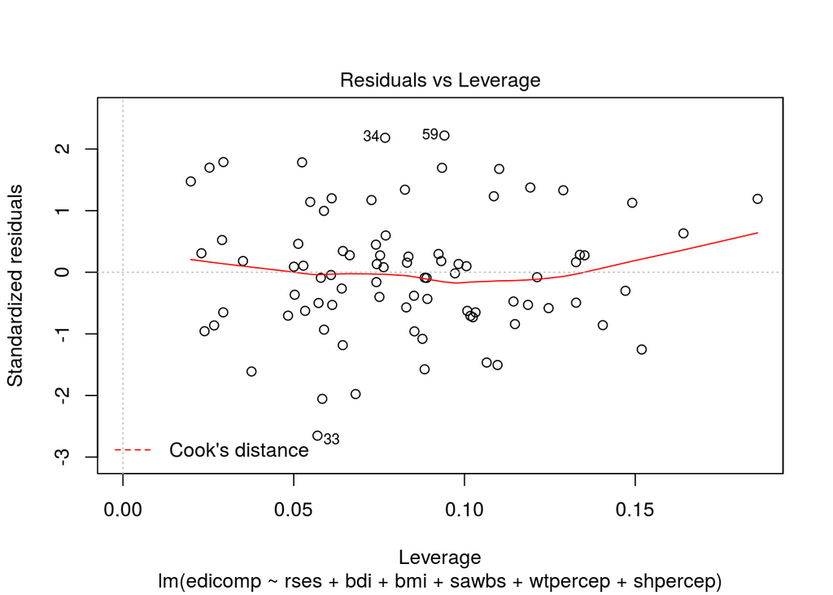

```r
plot(mod)
```

## Histogram and Q-Q plot

If you want to check the assumption of normality of the errors, you can create a histogram or Q-Q plot for the residuals.

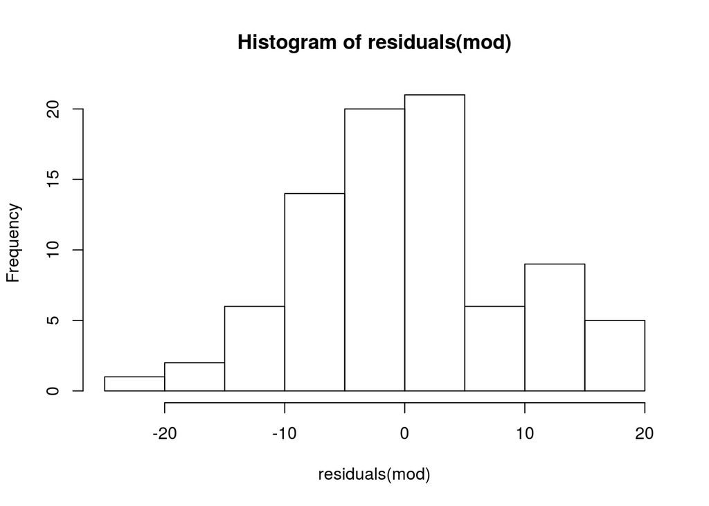

```r
hist(residuals(mod))
```

If you want a histogram with a Normal distribution overlaid, you can do this as

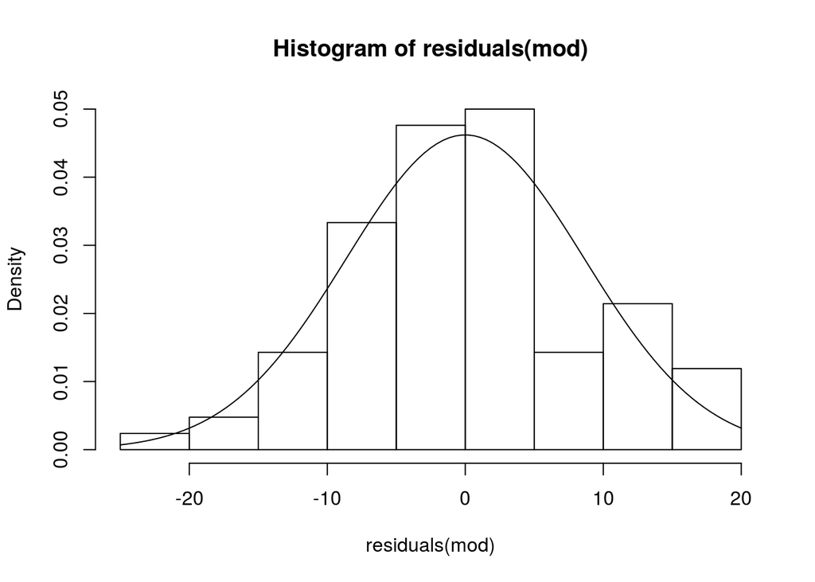

```r
hist(residuals(mod),prob=TRUE)
curve(dnorm(x,mean=0,sd=sd(residuals(mod))),add=TRUE)
```

A Q-Q-plot can be created as

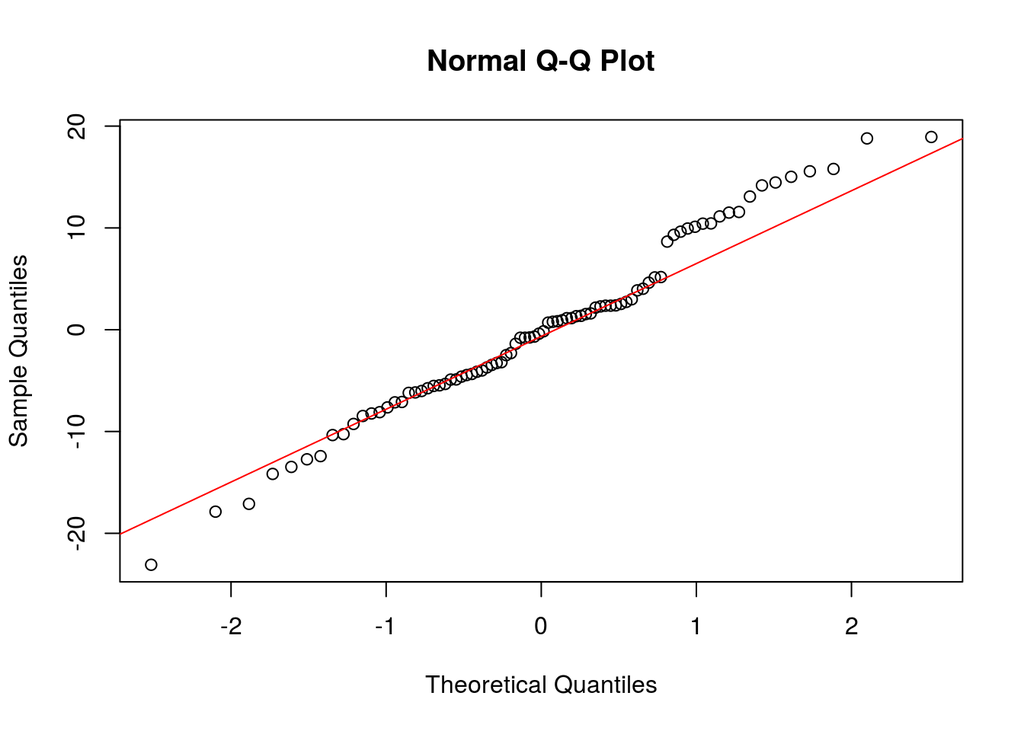

```r
qqnorm(residuals(mod))
qqline(residuals(mod), col = 2)
```

The Q-Q plot was also created in the output of the call to `plot` above. Finally, you can also use the “fancy” qqplot function I made available on Moodle.

## Test for Normality

You can perform the Shapiro-Wilks tests for Normality through the `shapiro.test` function. The more general, but less powerful, Kolmogorov-Smirnov test can be performed through the `ks.test` function.

```r
shapiro.test(residuals(mod))
```

```
##
##  Shapiro-Wilk normality test
##
## data:  residuals(mod)
## W = 0.98351, p-value = 0.3592
```

```r
ks.test(residuals(mod),"pnorm",mean=0,sd=sd(residuals(mod)))
```

```
##
##  One-sample Kolmogorov-Smirnov test
##
## data:  residuals(mod)
## D = 0.090797, p-value = 0.4657
## alternative hypothesis: two-sided
```

The results of the Kolmogorov-Smirnov and Shapiro-Wilk tests should not be significant. If they are, that means your residuals deviate significantly from a normal distribution.

## The Breusch-Pagan and Koenker tests

Follow the instructions in the file homoscedasticity.pdf on Moodle.